# Programming Assignment 2

# BONUS - Question 8 (3 points)

Create a function called `plot_species()` that takes in a species name (e.g. `"setosa"`) and creates a customized scatterplot using only flowers from that species.

The function should:

- Filter the dataset to include only the selected species
- Create a scatterplot showing:
  - Sepal length on the x-axis
  - Petal length on the y-axis
- Color points based on petal width
- Scale point size based on sepal width
- Add a smooth trend line (try ?geom_smooth)
- Add a title that dynamically includes the species name
- Add informative axis labels

Your function should work for all three species. Make sure to add proper function documentation.

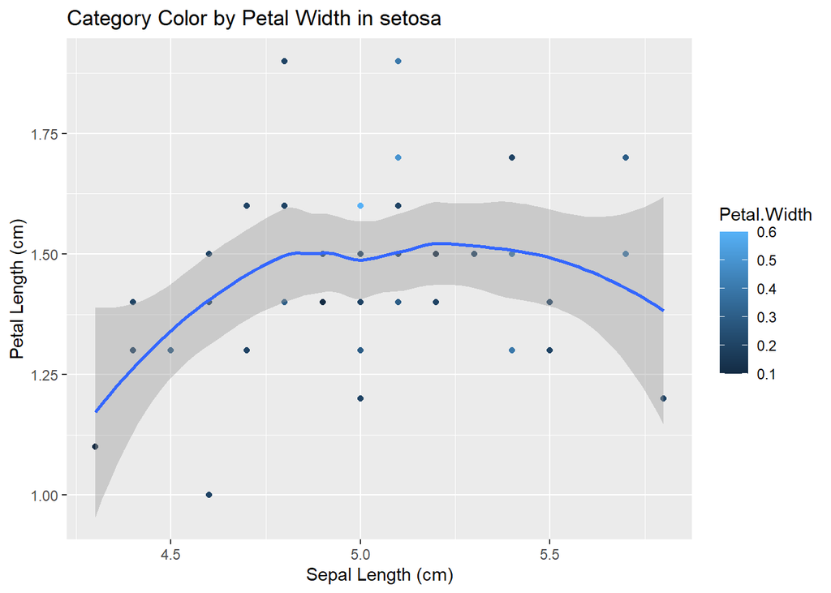

```r
plot_species <- function(FlowerName) {
  filtered_flowers = filter(flowers,Species==FlowerName)
ggplot(filtered_flowers, aes(x = Sepal.Length, y = Petal.Length, colour = Petal.Width)) +
  geom_point() +
  geom_smooth() +
  labs(
    title =paste0("Category Color by Petal Width in ", FlowerName),
    x = "Sepal Length (cm)",
    y = "Petal Length (cm)"
  )
}

# Test your function
print(plot_species("setosa"))
```

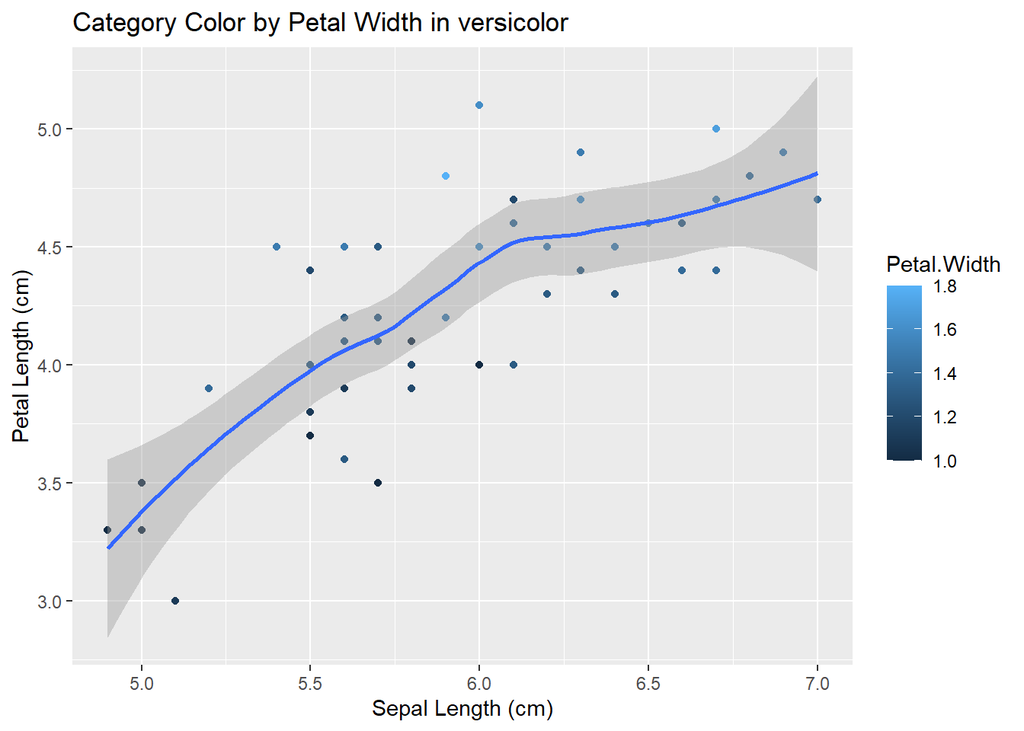

```r
print(plot_species("versicolor"))
```

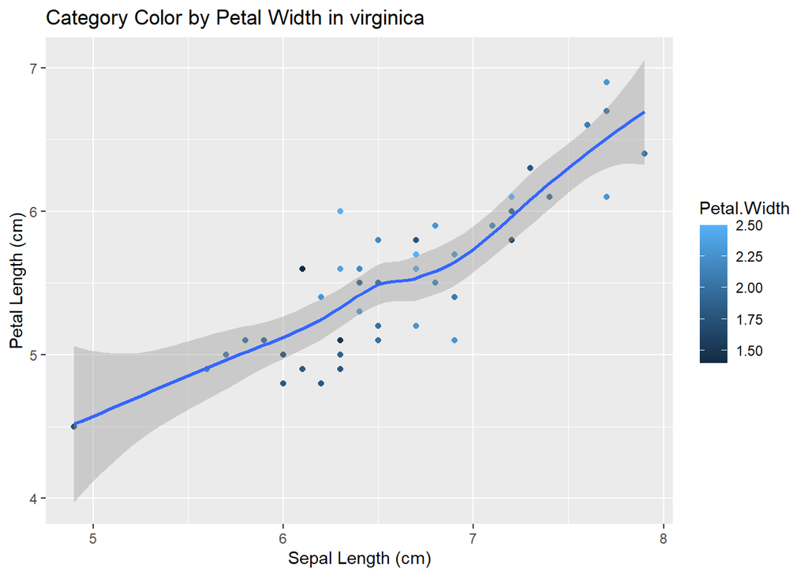

```r
print(plot_species("virginica"))
```

test

```r
?geom_smooth
```

```
## starting httpd help server ... done
```

[output not shown]